# Introdução a Renda Variável (Ações)

Ross et al. (2022), capítulo 08

Marcelo S. Perlin

EA-UFRGS

06/04/2026

# Introdução a contratos de sociedade

## Conceito

> Uma ação representa a menor parcela do capital próprio de uma sociedade por ações
- Vantagens:
  - Para o investidor: vira sócio da empresa e tem direito ao lucro obtido a cada exercício e a voto no conselho, entre outras coisas
  - Para a empresa: fonte de novo capital e novos sócios para compartilhar risco
- O preços das ações oscilam de acordo com novas informações que chegam ao mercado
- A precificação de ações é muito mais complicada que precificação de títulos de dívida devido à incerteza do lucro futuro das empresas

## Quanto você pagaria por 10% da renda vitalícia de um pessoa de 25 anos, recém-formada da UFRGS?

## Quanto você pagaria por 10% da renda vitalícia de um estudante desligado da Harvard após 2 anos de curso em 1975?

## Bill Gates

Patrimônio estimado: 129.900.000.000,00 USD

## Porque os preços das Ações mudam ?

> O preço de uma ação é simplesmente a soma do lucro esperado futuro, descontado para o presente
- Os fluxos de caixa das empresas são baseados em expectativas individuais
- As expectativas individuais de lucros futuros são construídas a partir das informações disponíveis:
  - Exemplo: Preços passados e demonstrativos financeiros
  - Notícias – ou novas informações – a respeito da empresa (e economia) mudam as expectativas dos agentes e consequentemente os preços das ações
- O preço atual de uma ação é o efeito da soma das expectativas dos agentes de mercado (investidores)

## Exemplo META/Facebook

[figure not shown]

Origem: [Bastter](https://bastter.com/mercado/basttergram/)

# Fluxos do dinheiro

## Principais Fluxos de Caixa para o Investidor

- **Proventos em dinheiro**
  - Dividendos
    - Geralmente acima de 25% do lucro líquido do exercício
    - Não deduzível para cálculo do IR da empresa
    - Isento IR para pessoa física (acionista) se renda total ABAIXO de 50k por mês
  - Juros sobre o Capital Próprio (JSCP)
    - Lei 9249 (1995) – Compensação da correção monetária dos Balanços Deduzível para cálculo de IR da empresa, incide IR para o investidor
    - Teto definido pela TJLP (Taxa de juros de longo prazo) multiplicada pelo PL
- **Venda da Ação**
  - Incide imposto de ganho de capital - na pessoa física, existe uma isenção para uma soma de vendas mensais menores que 20.000R$

## Fluxos de caixa na compra de TAEE11 (Taesa)

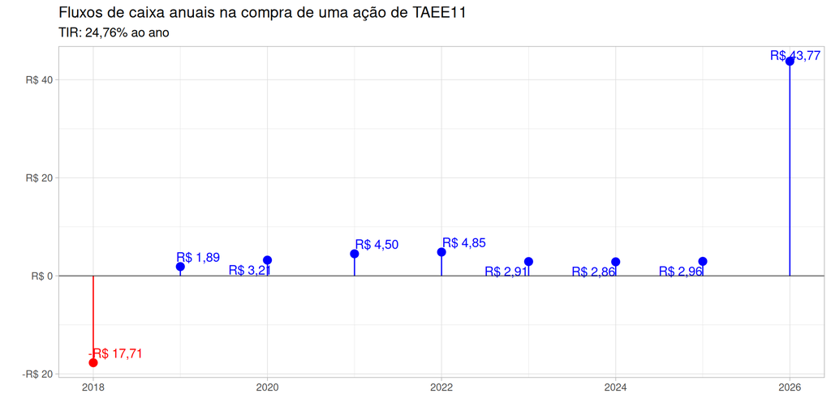

## Fluxos de caixa na compra de FIIB11 (FII Industrial do Brasil)

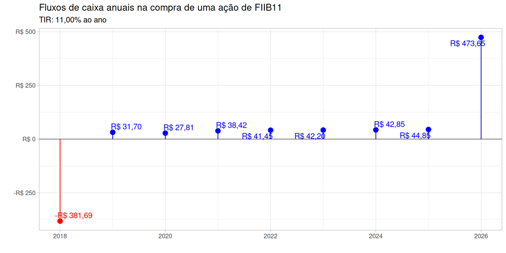

## Fluxos de caixa na compra de WEGE3 (WEGE SA)

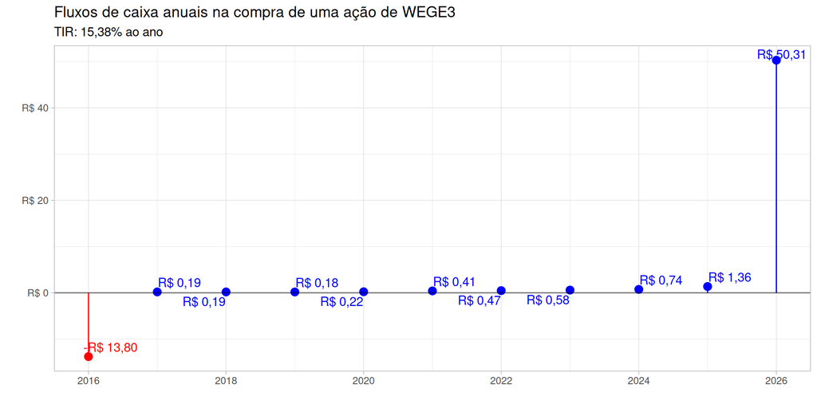

## Fluxos de caixa na compra de M. Dias (MDIA3)

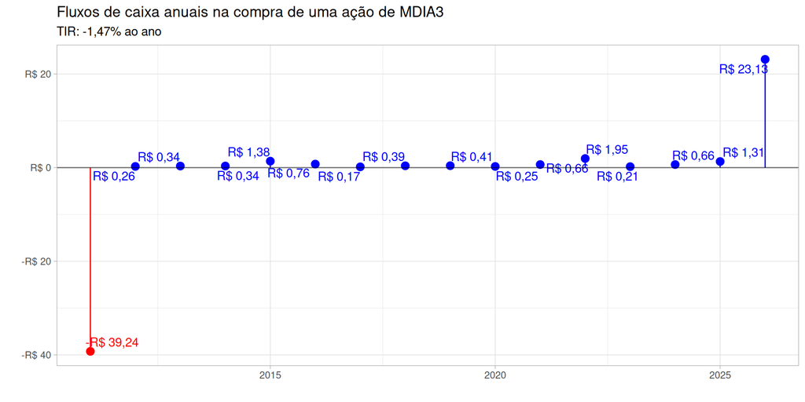

## Outros direitos do acionista

- **Subscrição**
  - Direito dos acionista na aquisição de novas ações (ou debêntures) com preço e prazo determinado
- **Bonificação**
  - Distribuição gratuita de novas ações aos acionistas, utilizando recursos próprios da empresa (reservas e/ou lucros)
- **Desdobramento ou *split***
  - Diluição do número de ações no mercado (ex: 1 -> 2)
  - geralmente uma boa notícia
- **Agrupamento ou *inplit***
  - Condensação do número de ações (ex: 2 -> 1)
  - geralmente uma má notícia

# Tipos de Ações

**Ações Ordinárias (ON)**

- Sem preferência nos pagamentos de dividendos
- Sem preferência no caso de falência da empresa
- Direito de voto em assembléia e tag along
- **Geralmente** são mais valiosas que ações preferenciais

**Ações Preferenciais (PN)**

- Preferência no pagamento de dividendos (dividendos pagos são maiores que para as ordinárias)
- Preferência para ressarcimento no caso de falência
- Não dão direito a voto em assembleia, porém tem direito de tag along

## O caso GERDAU

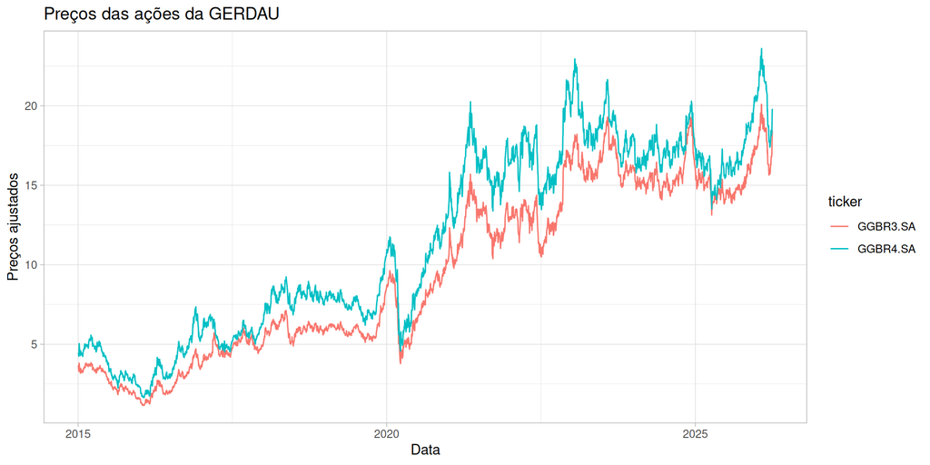

## Controle Atual da GERDAU

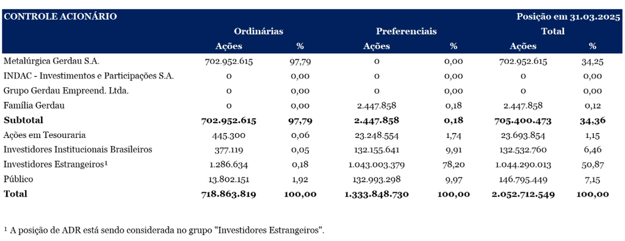

Dados retirados do [site RI](https://ri.gerdau.com/a-gerdau/composicao-acionaria/)

## Explicações

- A diferença de preços entre uma ação ordinária e preferencial é uma função de:
  - Valor do controle da empresa
  - Estrutura do controle da empresa
  - Histórico de pagamento de proventos (dividendos) pela empresa

# Segmentos do Mercado

## Mercado primário e secundário

- **Mercado Primário**
  - Ponto inicial de emissão de ações por parte de uma empresa
  - Caracteriza-se como uma oferta pública onde o dinheiro captado vai direto para o caixa da empresa
  - Geralmente participam apenas instituições financeiras. Porém, algumas corretoras permitem ao investidor comum participar também.
- **Mercado Secundário**
  - As ações já emitidas no mercado primário são comercializadas através das bolsas de valores
  - A empresa ainda se beneficia da alta dos preços pois geralmente uma parcela das ações são mantidas em tesouraria

## Ilustração

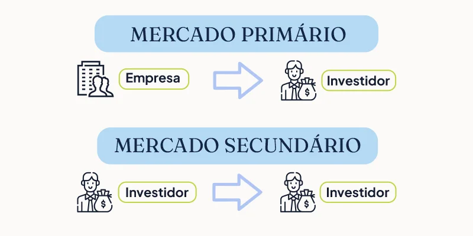

# A bolsa Brasileira (B3)

## Sobre a B3

> A B3 é instituição privada resultante da fusão da Bovespa com a BMF em 2008, e fusão com CETIP em março 2017 Principal instituição brasileira de intermediação para operações do mercado de capitais
- Desenvolve, implanta e provê sistemas para a negociação de instrumentos financeiros entre:
  - Ações
  - Mercadoria e futuro
  - Derivativos
  - Títulos de renda fixa
  - A própria B3 (antiga BM&Fbovespa) é negociada em bolsa (B3SA3)
- Percentual de participação de cada [tipo de investidor](https://arquivos.b3.com.br/bdi/tabelas/12-04-2024?classification=aeaccfe3-e492-40c4-9359-f9d6d2ef3ed9&table=SharesInvesVolumMonthly&lang=pt-BR)

## Referências

Ross, Stephen, Randolph Westerfield, Bradford Jordan, et al. 2022. *Fundamentos de Administração Financeira*. Bookman Editora.